# Bolt assessment

```python
import pandas as pd
import numpy as np
from datetime import datetime, timedelta

import scipy.stats as st

import matplotlib.pyplot as plt
import folium
from folium.plugins import HeatMap
import seaborn as sns
import plotly.express as px
from plotly.offline import iplot
from statsmodels.graphics.tsaplots import plot_pacf
from statsmodels.tsa.arima.model import ARIMA

from typing import List, Tuple, Any
```

```python
# Utils
def euclidian_distance(lat_1: float, lon_1: float, lat_2: float, lon_2: float) -> float:
  return np.sqrt( (lat_1 - lat_2)**2 - (lon_1 - lon_2)**2 )

def df_to_tuple(df: pd.DataFrame) -> List[Tuple]:
  return df.to_records(index=False).tolist()


def build_lat_lon_grid(lng_interval: Tuple, lat_interval: Tuple, weekday: int = 0, hour: int = 12, N: int = 10) -> Tuple:
  '''
  Build a dataframe ready to use for density prediction
  '''

  # Create grid
  xmin, xmax = lng_interval[0], lng_interval[1]
  ymin, ymax = lat_interval[0], lat_interval[1]
  xx, yy = np.mgrid[xmin:xmax:N*1j, ymin:ymax:N*1j]

  # Stack
  positions = np.vstack([xx.ravel(), yy.ravel()])

  # Create dataframe
  X_test = pd.DataFrame(positions.T, columns = ['start_lng', 'start_lat'])
  X_test['weekday'] = weekday_predict
  X_test['hour'] = hour_predict
  return X_test, xx, yy
```

```python
class Plotter:

  @staticmethod
  def plot_daily_cycle(hourly_count: pd.DataFrame, column: Any = 'count', title: str = 'Daily cycle', ylabel: str = '') -> None:
    '''
    Plot stacked hourly count to visualize daily cycle
    '''
    hourly_count['hour'] = hourly_count.index.hour
    hourly_count['day'] = hourly_count.index.day
    pivot = pd.pivot_table(hourly_count, index='hour', columns='day', values=column)

    pivot.plot(legend=False, color='black', alpha=.2, figsize=(10, 5))
    plt.title(title, fontweight='bold')
    plt.grid(linestyle=':')
    plt.ylabel(ylabel, fontweight='bold')



  @staticmethod
  def plot_scatter_map(latlon_list: List[Tuple]) -> None:
    '''Scatter plot on Tallinn map'''

    # Initialize the Map instance centered on Tallinn
    m = folium.Map(location=[59.436300, 24.746963],zoom_start=12, control_scale=True,tiles="cartodbpositron")

    # Plot points
    for coord in latlon_list:
        folium.Marker( location=[ coord[0], coord[1] ], fill_color='#43d9de', radius=8 ).add_to( m )
    return m


  @staticmethod
  def plot_heatmap(latlon_list: List[Tuple]) -> None:
    # Initialize the Map instance centered on Tallinn
    m = folium.Map(location=[59.436300, 24.746963],zoom_start=12, control_scale=True,tiles="cartodbpositron")

    HeatMap(latlon_list).add_to(m)
    return m


  @staticmethod
  def plot_contour_distribution(xx, yy, zz, xlim: Tuple, ylim: Tuple, title: str = '') -> None:

    # Plot density
    f = np.reshape(zz, xx.shape)

    fig = plt.figure(figsize=(10, 10))
    ax = fig.gca()
    ax.set_xlim(xmin, xmax)
    ax.set_ylim(ymin, ymax)
    cfset = ax.contourf(xx, yy, f, cmap='Blues')
    cset = ax.contour(xx, yy, f, colors='k')

    # Label plot
    ax.clabel(cset, inline=1, fontsize=10)
    ax.set_xlabel('Latitude', fontweight='bold')
    ax.set_ylabel('Longitude', fontweight='bold')
    ax.grid(linestyle=':')
    ax.set_title(title, fontweight='bold')

    plt.show()
```

```python
class DataLoader:

  @staticmethod
  def load_data() -> pd.DataFrame:
    '''Simply load data and build additional faetures'''

    df = DataLoader._load_raw()
    df = DataLoader._build_calendar(df=df)
    df = DataLoader._build_additional_features(df=df)
    return df

  @staticmethod
  def load_meteo():
    '''Load meteo information'''
    df = pd.read_csv('drive/MyDrive/ColabNotebooks/BoltAssessmentData/tallinn_meteo.csv')
    df.rename(columns = {'t': 'temperature', 'ghi': 'radiation', 'tp': 'precipitation'}, inplace=True)
    df['hourlydate'] = pd.to_datetime(df['hourlydate'])
    df = df.set_index('hourlydate')
    df = df[['temperature', 'radiation', 'precipitation']]
    df = df.resample('H').mean()
    return df

  @staticmethod
  def _load_raw(path: str = 'drive/MyDrive/ColabNotebooks/BoltAssessmentData/robotex5.csv') -> pd.DataFrame:
    df = pd.read_csv(path)
    df['start_time'] = pd.to_datetime(df['start_time'], format='%Y-%m-%d %H:%M:%S')
    df.set_index('start_time', inplace=True)
    return df


  @staticmethod
  def _build_calendar(df: pd.DataFrame) -> pd.DataFrame:
    df['valuedate'] = df.index.normalize()
    df['hour'] = df.index.hour
    df['minute'] = df.index.minute
    df['day'] = df.index.day
    df['weekday'] = df.index.weekday
    df['hourlydate'] = [d + timedelta(hours=h) for (d,h) in zip(df['valuedate'], df['hour'])]
    return df

  @staticmethod
  def _build_additional_features(df: pd.DataFrame):
    df['distance'] = euclidian_distance(lat_1 = df['start_lat'], lon_1 = df['start_lng'], lat_2 = df['end_lat'], lon_2 = df['end_lng'])
    return df


class DataContainer(DataLoader):
    def __init__(self) -> None:
      super().__init__()

      self._values = {}
      self._values['data'] = super().load_data()
      self._values['meteo'] = super().load_meteo()

    def __getitem__(self, item):
      return self._values[item]

    def __setitem__(self, key, value):
      self._values[key] = value
```

```python
# Load and store dataframe
data_container = DataContainer()
data_container['weekly_count'] = data_container['data'].groupby('weekday').count()['start_lat']
data_container['hourly_count'] = data_container['data'].resample('H').count()['start_lat'].to_frame('count')
data_container['daily_count'] = data_container['data'].resample('D').count()['start_lat'].to_frame('count')
data_container['hourly_ride_value'] = data_container['data'].resample('H').mean()['ride_value'].to_frame('ride_value')
data_container['hourly_mean'] = data_container['data'].resample('H').mean()
data_container['meteo'] = data_container.load_meteo()
```

# Data Analysis

The dataset constist in demand requests made by users on **March 2022**.

We can easily analyze temporal pattern aggregating data with respect to space to detect global behaviour of the demand.

## Time properties

By a simple exploration we notice the following properties:

- **Increasing trend** this seems actually an yearly cyclic trend. It should be evident if we analyze yearly data.
- **Weekly and daily seasonality**
- **Lower demand during monday and higher on saturday**
- **Daily cycle** characterized by three peaks: early morning (hour 7), mid afternoon (hour 16), late night (hour 22).

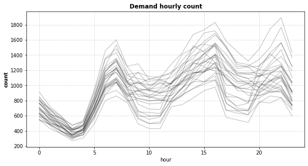

```python
Plotter.plot_daily_cycle(hourly_count = data_container['hourly_count'], title = 'Demand hourly count', ylabel='count')
```

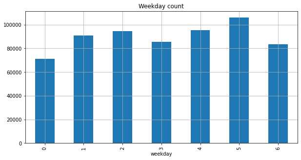

```python
data_container['weekly_count'].plot.bar(title='Weekday count', figsize=(10, 5), grid=True)
```

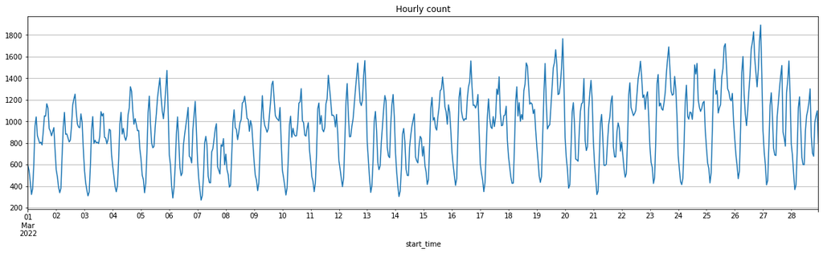

```python
ax = data_container['hourly_count']['count'].plot(figsize=(20, 5), title = 'Hourly count', grid=True)
```

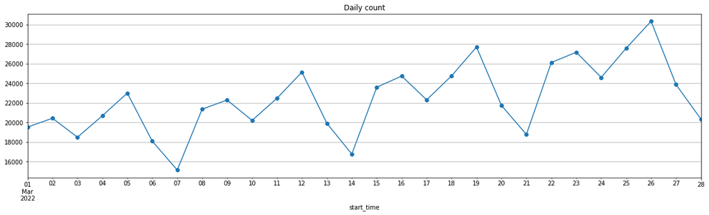

```python
data_container['daily_count']['count'].plot(figsize=(20, 5), marker='o', grid=True, title='Daily count')
```

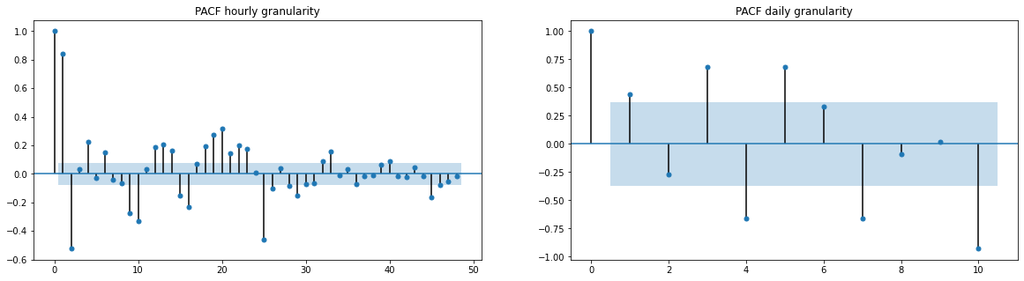

```python
fig, ax = plt.subplots(1, 2, figsize=(20, 5))
_=plot_pacf(data_container['hourly_count']['count'], lags=48, title='PACF hourly granularity', ax=ax[0])
_=plot_pacf(data_container['daily_count']['count'], lags=10, title='PACF daily granularity', ax=ax[1])
```

## Space properties

I look for spatial pattern during the day. In particular if the demand distribution behave differently for different hour of the day.

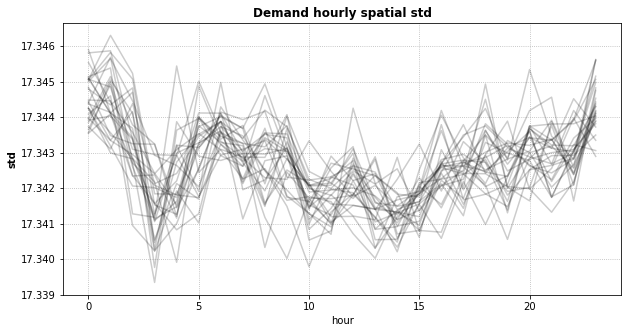

```python
# Build timeseris of spatial std of the demand distribution
std_df = pd.Series(np.nan, index=data_container['data']['hourlydate'].unique()).sort_index()
for h, df in data_container['data'].groupby('hourlydate'):
  std_df[h] = np.std(df[['start_lat', 'start_lng']].values)
std_df = std_df.to_frame('space_std')
std_df.index = pd.to_datetime(std_df.index)

# Visualize spatial std by hour
Plotter.plot_daily_cycle(hourly_count = std_df, column = 'space_std', title = 'Demand hourly spatial std', ylabel = 'std')
```

I also study the distribution of the distance (straight line) of the trips of the customers.

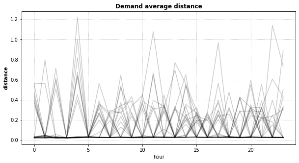

```python
Plotter.plot_daily_cycle(hourly_count = data_container['hourly_mean'], column = 'distance',title = 'Demand average distance', ylabel='distance')
```

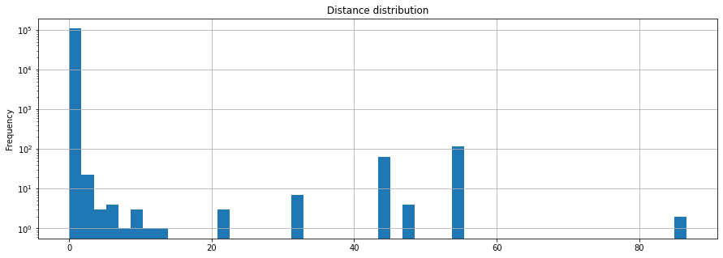

```python
data_container['data']['distance'].plot(kind='hist', logy=True, bins=50, grid=True, figsize=(15, 5), title='Distance distribution')
```

# Baseline model

In order to let drivers understand very clearly the output of the model I've decided to design a very simple model consisting of two layers:

1. **Time Layer**: This part of the model takes care of forecasting the hourly aggregated demand (aggregated with respect to space). This is a classical 1D timeseries forecasting problem.
2. **Spatial Layer**: In this layer we compute the average of the distributions of requests made in the same *time class*. Namely I' ve decided to approximate the distribution of a given day and hour with the average of the distributions observed in the past (at similar hours and day).

## Time Layer

Let $d_s$ the request made by a custemer at time $s$. We define then $D_t = \{ d_s | s \in [t, t+1)\}$.

Our target is then the timeseries of the cardinality of the requests made in a given hour.

$$ y_t = |D_t| $$

In order to keep it simple I've decided to use a SARIMA to forecast this quantity. In particular, since I am considering hourly timeseries and I know that there is a weekly seasonality, I use a seasonal term $m=168$.

```
(Text(0.5, 0, 'Date'), Text(0, 0.5, 'Demand count'))
```

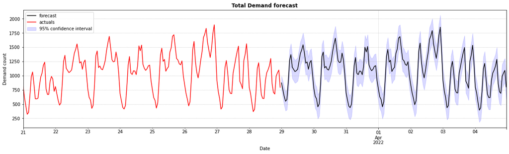

```python
# Fit ARIMA model with seasonal order 168 (7 * 24)
mdl = ARIMA(data_container['hourly_count']['count'], order = (3, 1, 1), seasonal_order = (1, 0, 0, 168))
mdl_fitted = mdl.fit()

# Predict 1 week after last observation
start = data_container['hourly_count']['count'].index.min()
end = data_container['hourly_count']['count'].index.max()
count_predict = mdl_fitted.predict(start=start, end = end+timedelta(days=7), dynamic=False)

# Confidence interval
count_predict_conf_interval = mdl_fitted.get_forecast(7*24).conf_int(alpha=0.05)

# Visualize last week observation and forecast
ax = count_predict[datetime(2022, 3, 29):].plot(color='black', figsize = (20, 5), label='forecast')
ax.fill_between(x = count_predict_conf_interval.index, y1=count_predict_conf_interval['lower count'], y2=count_predict_conf_interval['upper count'], color='blue', alpha=.15, label='95% confidence interval')
data_container['hourly_count']['count'][datetime(2022, 3, 21):].plot(ax=ax, color='red', label='actuals')
ax.grid(linestyle=':')
ax.legend()
ax.set_title('Total Demand forecast', fontweight='bold')
ax.set_xlabel('Date'), ax.set_ylabel('Demand count')
```

**In conclusion** we have a model that, given data of the past customers demands, can forecast the global hourly demand.

Of course we can change forecast granularity by simply aggregating at different granularity (and of course changing the seasonal order of the SARIMA) or upscaling the hourly forecast via interpolation.

## Spatial Layer

To build this layer I follow these two steps

1. Time mapping
2. Distribution aggregation

The main idea is to map similar hours and days to the same class. For each class $C$ we can estimate the demands spatial distribution and compute the average of these distributions among all valuedate belonging to the same time class.

Let $\mathcal{D}_C(x)$ the distribution associated to class $C$ defined as:

$$ \mathcal{D}_C(x)= \frac{1}{|C|}\sum_{s \in C} f_s(x) $$

where $f_s(x)$ is the demand density at time $s$.

In practive I've decided to estimate $f_s(x)$ using a Gaussian Kernel Density Distribution fitted on hourly aggregated data.

```python
# Example heatmap at hour 12 on weekday 0
data_slice = data_container['data'].loc[(data_container['data']['hour']==12) & (data_container['data']['weekday']==0), :]
pp = df_to_tuple(data_slice[['start_lat', 'start_lng']])
m = Plotter.plot_heatmap(pp)
m
```

[output not shown]

```python
class GaussianKdeVector:
  def __init__(self, kde_list: List) -> None:
    self._kde_list = kde_list
    self._N = len(kde_list)
    return

  def __call__(self, p):
    kde_density_list = [k(p) for k in self._kde_list]
    kde_density_matrix = np.stack(kde_density_list, axis=0)
    kde_density_mean = np.mean(kde_density_matrix, axis=0)
    return kde_density_mean




class ClassAverageDistribution:

  def __init__(self) -> None:
    self._distribution_class = {}
    self._distribution_list = {}
    self._map_vertex = {'x': None, 'y': None}
    return



  def fit(self, X: pd.DataFrame, verbose: bool = False) -> None:
    '''
    Fit distribution average for each class
    '''

    for i, df in X.groupby(by=['weekday', 'hour']):

      if verbose:
        print(f'Train class: weekday {i[0]}, hour {i[1]}. Samples {len(df)}')

      density_list = []
      for d, df_tmp in df.groupby('valuedate'):
          df_raw = df_tmp[['start_lng', 'start_lat']].values.T

          kernel = st.gaussian_kde(df_raw, bw_method = 'scott')
          density_list.append(kernel)

      # Store KDE vector
      self._distribution_class[i] = GaussianKdeVector(kde_list = density_list)
      self._distribution_list[i] = density_list

    # Store train vertex
    self._map_vertex['x'] = [X['start_lat'].min(), X['start_lat'].max()]
    self._map_vertex['y'] = [X['start_lng'].min(), X['start_lng'].max()]



  def predict(self, X: pd.DataFrame) -> pd.DataFrame:
    '''
    Predict demand density for each sample
    '''

    prediction_list = []

    # Generate prediction for each bucket (hour, weekday)
    for i, df in X.groupby(by=['weekday', 'hour']):

      point_tmp = X[['start_lng', 'start_lat']].values.T
      density_prediction = self._distribution_class[i](point_tmp)
      df['density_predict'] = density_prediction
      prediction_list.append(df)

    prediction_output = pd.concat(prediction_list, axis=0)

    return prediction_output


  def _data_check(df: pd.DataFrame):
    '''Make sure data have correct structure'''
    return
```

```python
# Train model
X_train = data_container['data'].copy()

model = ClassAverageDistribution()
model.fit(X=X_train)
```

```python
# Example of prediction for a certain weekday and hour
weekday_predict = 5
hour_predict = 12

xmin, xmax = X_train['start_lng'].min(), X_train['start_lng'].max()
ymin, ymax = X_train['start_lat'].min(), X_train['start_lat'].max()

X_test, xx, yy = build_lat_lon_grid(lng_interval = (xmin, xmax), lat_interval = (ymin, ymax), weekday=weekday_predict, hour=hour_predict, N = 100)
```

```python
prediction = model.predict(X = X_test)
```

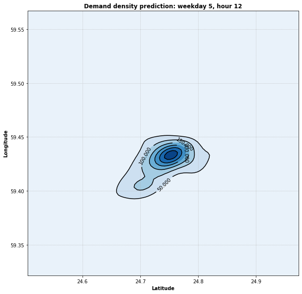

```python
Plotter.plot_contour_distribution(xx = xx, yy=yy, zz = prediction['density_predict'].values, xlim = (xmin, xmax), ylim = (ymin, ymax),
                                  title = f'Demand density prediction: weekday {weekday_predict}, hour {hour_predict}')
```

# Deployment

Because of the strong autoregressive nature of the model it's very important being able to calibrate the model in order to deliver updated forecast to the drivers.

These are the main points that should characterised the deployment:

1. Both drivers and users comunicate with Bolt's server (and thus model) using App.
2. Model prediction should be sent in real time so that drivers can query always updated values (and take decisions based on them).
3. Model must have access to updated demand data to perform a correct real-time calibration

I the model should be deployed using **Docker container**. The model will be retrained as soon as data are collected.

Since I' ve decided to use hourly granularity also the update will be hourly.

Since the model is constantly calibrating I would use also a system to monitor main metrics such as:

1. Error committed by the model in the past.
2. Weights of SARIMA model
3. Execution time

I would use *MLflow* to build this monitoring system.

In the following diagram I've tried to summarize the whole chain:

[figure not shown]

# Communicate result to drivers

Of course the main interface should be the Bolt App.

I suppose drivers already heavily use the app in order to accept request sent by customers.

I would design a page in the app, let's call it **"Monitor Dashboard"**.

This page should be easily accessible (I would say it should be the main page for drivers).

Infact it should work as *waiting room* for drivers: a page they can open while waiting for a customer request.

From this page they can have access to model metrics and they should be able to easily understand the outcome.

In case they receive a request they will be notified via pop up message. If they accept the app will automatically switch from **Monitor Dashboard** to the usual interface they use when dealing with a customer.

I would organize the page as follow:

1. On top a plot of the timeseries of total demand showing the forecast of the next 7 days. From this plot drivers have all the informations to organize their day and week. Namely they can decide when they want to be active according to the demand peaks.
2. On the bottom a map showing the current position of the driver and the areas of the city with higher demand forecast density in the next hour. This map should be 2/3 of the page. It will helps the driver to find area with higher demand (and thus higher probability to be matched). It is also convenient for the driver to be in these area to minimize the reach time.

### Readability

I would avoid showing the driver too much informations. For example I would NOT use a heatmap that contains too much informations that are hard to exploit. Also I would NOT show the forecast for time hirozon far away to avoid driver s take decsions on values that are not very reliable (because of the high lead time).

I would also avoid any kind of back test performance metrics (such as RMSE for demand forecast) to avoid confuse drivers that do not know these concept.

**In conclusion** with a simple page in the app we let the driver organizes both his time and his position. Implicitly we also suggest the better position the driver should reach to achieve higher earnings and thus the optimal "strategy" from the driver point of view.

[figure not shown]

# Validation

I end up dealing with a supervised timeseries forecasting problem. The output of the model is calibrated according to the past demand data and do not depend on supply.  
**It can be easily validated by computing performance of last observations.** I would of course perform a backtest on the historical data to get some statistics on the past. When model is deployed to deliver online forecast I would compare the error committed in the last few days with the error committed in the same period in the backtest.

In this way I could **monitor the live error**, eventually find some recurrent bias pattern, and **compare the live error with the hystorical error**. If the historical error is way lower I can then investigate the reasons: error during model calibrations, something particular happened in the city.

In practive I would use the following metrics:

- **RMSE** for global demand time series forecast.
- **Kullback-Leibler divergence** for demand spatial distribution.

# Next steps

There are a lot of things that can be done to improve this model. Here I will list few ideas that came in my mind while working on it:

1. Improve demand forecast using metereological features. It makes sense that demand depend on temperature, solar radiation and rain. Using meteo forecast it should be easy to improve demand forecast (**see below**)
2. Demand do not depend by this model, but supply does. Infact if all the drivers receive the same notification about an "high density demand zone" then the offer will be conditionated. Namely there will be an over-supply for that zone.  
   The raccomandation model should be then integrate with some reward factor to take in account the other drivers. The problem should become a **game theory problem**.
3. In order to optimize dirver earning trip time and arrival point must be taken in account. For a driver, if two trips have the same length it would be better to take the one with arrival point close to an high density region at arrival time.  
   Furthermore for a driver it could be more convenient accept a trip at certain time so that the arrival time conincide with a demand peak, in this way he will be sure to receive in very short time a new request.

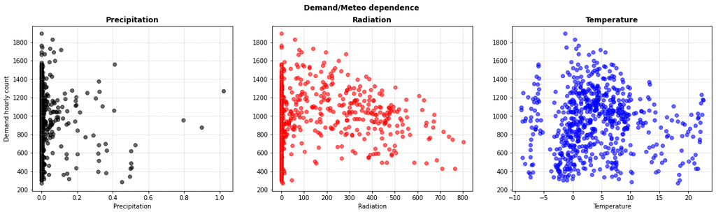

```python
# Visualize meteo dependence

# Concat hourly demand with meteo
meteo_comparison = pd.merge(data_container['hourly_count'], data_container['meteo'], left_index=True, right_index=True, how='left')


# Plot image
fig, ax = plt.subplots(1, 3, figsize=(20, 5))
ax[0].scatter(x = meteo_comparison['precipitation'], y=meteo_comparison['count'], color='black', alpha=.6)
ax[0].set_xlabel('Precipitation')
ax[0].set_ylabel('Demand hourly count')
ax[0].set_title('Precipitation', fontweight='bold')

ax[1].scatter(x = meteo_comparison['radiation'], y=meteo_comparison['count'], color='red', alpha=.6)
ax[1].set_xlabel('Radiation')
ax[1].set_title('Radiation', fontweight='bold')

ax[2].scatter(x = meteo_comparison['temperature'], y=meteo_comparison['count'], color='blue', alpha=.6)
ax[2].set_xlabel('Temperature')
ax[2].set_title('Temperature', fontweight='bold')

ax[0].grid(linestyle=':')
ax[1].grid(linestyle=':')
ax[2].grid(linestyle=':')

fig.suptitle('Demand/Meteo dependence', fontweight = 'bold')
```